# Fitting the ST model for the LUR

Sheena Martenies

3/19/2020

### Description:

After meeting with Josh Keller (Statistics, CSU), we decided to try to implement the modeling framework used by the MESA Air team (Keller et al., 2015). This was implemented using the SpatioTemporal package in R.

The original paper used PLS to select the spatial covariates. That will be the eventual approach for this analysis, but for now, I’m going to use the covariates selected by the LASSO model (see 16a_LUR_BC_average.R)

Basically, I’m going to start with the following:

- Simple model (i.e., only one time trend)
- iid covariance structure

**Update 03.24.20**: Sheryl and I met with Josh Keller again today to go over the premliminary verison of the model and talk about next steps. Here are some of the take-aways from the meeting:

- We should add the entirety of the BC monitoring data at the central site to help establish long-term time trends
- We need to add degrees of freedom to the time trends. Josh recommended 4 per year (but we can also try 8, 12, etc.). Time trends will become more obvious with more data
- I need to use the PM and NO2 monitoring data to establish temporal trends. These are different from the ST predictors! Start by plotting the time trends of PM, temp, and NO2. We might want to use PM for the temporal trends and NO2 and Temp as ST predictors (other combinations might work too, such as adding PM to the ST predictors). Don’t use BC as a ST predictor
  - When looking at the temporal trends, use `createSTdata`
  - Need to standardize PM and NO2
  - When ready to create the `STdata` object for model fitting, assign the temporal trend dataset to the `$trend` slot of the `STdata` object
- We also want to run a model without ST predictors as a comparison
- Make the LUR function the same for the intercept and the time trends
- Rather than set `nugget = ~type`, set `nugget = T`
- Change from the `iid` covariance structure to the `exp` structure
- Run a number of initial conditions to try to find the right minimum
  - For nuggets, set them to between -1 and -6
  - For ranges, set them to between 0 and 4
- Cross validation!
  - For distributed sites, use 10-fold CV
  - For central site, use LOOCV
- There is a trade-off for the number of basis functions selected. For now, I’m going to stick with one, and then we can see if more make sense later

I’m going to stick with the LASSO-selected spatial predictors for now. In the future, I’ll be implementing PLS.

### Step 1. Data formatting

Josh Keller made key revisions to the estimate.STmodel() function. Loading his version here and examining the objects from the `SpatioTemporal` package

```r
source(here::here("Code", "functions_model.R"))

data(mesa.data.raw, package="SpatioTemporal")
names(mesa.data.raw)
```

```
## [1] "X"             "obs"           "lax.conc.1500"
```

```r
head(mesa.data.raw$X) # Spatial covariates
```

```
##         ID         x        y     long     lat type log10.m.to.a1
## 1 60370002 -10861.67 3793.589 -117.923 34.1365  AQS      2.861509
## 2 60370016 -10854.95 3794.456 -117.850 34.1443  AQS      3.461672
## 3 60370030 -10888.66 3782.332 -118.216 34.0352  AQS      2.561133
## 4 60370031 -10891.42 3754.649 -118.246 33.7861  AQS      3.111413
## 5 60370113 -10910.76 3784.099 -118.456 34.0511  AQS      2.762193
## 6 60371002 -10897.96 3797.979 -118.317 34.1760  AQS      2.760931
##   log10.m.to.a2 log10.m.to.a3 log10.m.to.road km.to.coast
## 1      4.100755      2.494956        2.494956   15.000000
## 2      3.801059      2.471498        2.471498   15.000000
## 3      3.695772      1.830197        1.830197   15.000000
## 4      2.737527      2.451927        2.451927    1.023311
## 5      3.687412      2.382281        2.382281    6.011075
## 6      4.035977      1.808260        1.808260   15.000000
##   s2000.pop.div.10000
## 1            1.733283
## 2            1.645386
## 3            6.192630
## 4            2.088930
## 5            7.143731
## 6            4.766780
```

```r
class(mesa.data.raw$X)
```

```
## [1] "data.frame"
```

```r
head(mesa.data.raw$obs) # Observations at each sampling site (wide: time vs. location)
```

```
##            60370002 60370016 60370030 60370031 60370113 60371002 60371103
## 1999-01-13 4.577684 4.131632       NA       NA 4.727882 5.352608 5.281452
## 1999-01-27 3.889091 3.543566       NA       NA 4.139332 4.876832 4.846044
## 1999-02-10 4.013020 3.632424       NA       NA 4.054051 4.717611 4.665429
## 1999-02-24 4.080691 3.842586       NA       NA 4.392799 4.877139 4.830275
## 1999-03-10 3.728085 3.396944       NA       NA 3.960577 4.252480 4.163820
## 1999-03-24 3.751913 3.626161       NA       NA 3.958741 4.180627 4.240120
##            60371201 60371301 60371601 60371602 60371701 60372005 60374002
## 1999-01-13 4.984585 5.463134 5.316398       NA 5.081886 4.900640 4.995868
## 1999-01-27 4.100073 5.213077 5.010987       NA 4.674858 4.381561 4.785056
## 1999-02-10 4.056365 5.037477 4.770632       NA 4.715861 4.247208 4.493267
## 1999-02-24 4.382803 5.127157 4.960104       NA 4.905827 4.450186 4.440054
## 1999-03-10 3.808937 4.656825 4.205851       NA 4.403685 3.792204 4.035339
## 1999-03-24 3.794791 4.583794 4.383694       NA 4.472207 3.836844 3.995005
##            60375001 60375005 60590001 60590007 60591003 60595001 L001 L002
## 1999-01-13 5.165070       NA 4.847385       NA 4.603461 4.834629   NA   NA
## 1999-01-27 4.784252       NA 4.517424       NA 4.414679 4.576023   NA   NA
## 1999-02-10 4.685089       NA 4.217816       NA 4.104592 4.337169   NA   NA
## 1999-02-24 4.676942       NA 4.565771       NA 4.288501 4.573462   NA   NA
## 1999-03-10 4.030772       NA 3.816688       NA 3.374445 3.936019   NA   NA
## 1999-03-24 4.200838       NA 3.795629       NA 3.412111 3.914319   NA   NA
##            LC001 LC002 LC003
## 1999-01-13    NA    NA    NA
## 1999-01-27    NA    NA    NA
## 1999-02-10    NA    NA    NA
## 1999-02-24    NA    NA    NA
## 1999-03-10    NA    NA    NA
## 1999-03-24    NA    NA    NA
```

```r
class(mesa.data.raw$obs)
```

```
## [1] "matrix"
```

```r
head(mesa.data.raw$lax.conc.1500) # ST covariates-- in this case, the CALINE output
```

```
##            60370002 60370016 60370030 60370031 60370113 60371002 60371103
## 1999-01-13   2.3188        0   8.0641   0.1467   2.9894   1.7453   3.0796
## 1999-01-27   1.8371        0   7.3568   0.2397   4.7381   2.7741   4.0758
## 1999-02-10   1.4886        0   6.3673   0.2463   4.3922   2.6177   3.6573
## 1999-02-24   2.5868        0   7.1783   0.1140   3.3456   1.9160   2.7983
## 1999-03-10   1.8996        0   6.3159   0.1537   3.8495   2.2434   3.2737
## 1999-03-24   2.0162        0   6.3277   0.1906   3.2170   1.8760   2.8313
##            60371201 60371301 60371601 60371602 60371701 60372005 60374002
## 1999-01-13        0   4.3355   3.6514   1.6551   0.6840        0   8.3220
## 1999-01-27        0   3.5998   5.8899   2.4706   0.9682        0   6.5495
## 1999-02-10        0   2.8850   4.9941   2.0764   1.1398        0   5.1438
## 1999-02-24        0   4.0051   4.3535   1.9590   0.2790        0   7.5118
## 1999-03-10        0   3.4102   4.4792   1.9948   0.5782        0   6.3891
## 1999-03-24        0   3.1945   4.5385   1.8718   0.8634        0   5.5717
##            60375001 60375005 60590001 60590007 60591003 60595001   L001
## 1999-01-13   9.1542   0.0290   8.0984   2.8260        0   0.2097 3.0659
## 1999-01-27  14.9277   0.0434   6.1531   4.3818        0   0.2061 3.9648
## 1999-02-10  13.3726   0.0550   4.9165   4.4104        0   0.1500 3.5801
## 1999-02-24  10.1036   0.0285   6.9086   3.0511        0   0.2107 2.7203
## 1999-03-10  10.9733   0.0394   6.1697   3.5513        0   0.1748 3.1925
## 1999-03-24  11.5783   0.0334   5.3485   3.0596        0   0.2003 2.7244
##               L002  LC001 LC002   LC003
## 1999-01-13 16.1820 1.4743     0 12.4700
## 1999-01-27 19.0448 2.2429     0 21.7796
## 1999-02-10 15.4424 2.3170     0 22.2238
## 1999-02-24 21.4637 1.6237     0 13.3942
## 1999-03-10 18.1867 1.8615     0 15.8166
## 1999-03-24 16.9203 1.6814     0 18.0503
```

```r
class(mesa.data.raw$lax.conc.1500) # Separate matrices for each predictor
```

```
## [1] "matrix"
```

Get my data to match the Mesa data set. When I ran this the first time, Site 61 looked much different from the others, so I dropped it for now. I’ll need to go back and figure out what was wonky about that site later.

Loading the data sets needed for the analysis. Filtering out indoor filters, filters missing spatial data, and filters with BC concentrations below 0.

Something is going on with Site 61. When calculating the beta fields, I got results that were an order of magnitude larger than for the other sites. How does this site differ from the others?

The plots below suggest that maybe there is a different temporal pattern at this site? It’s not far from other sites, but we only have one campaign’s worth of data here. I’m going to drop it for now, but I’ll plan to come back to this eventually.

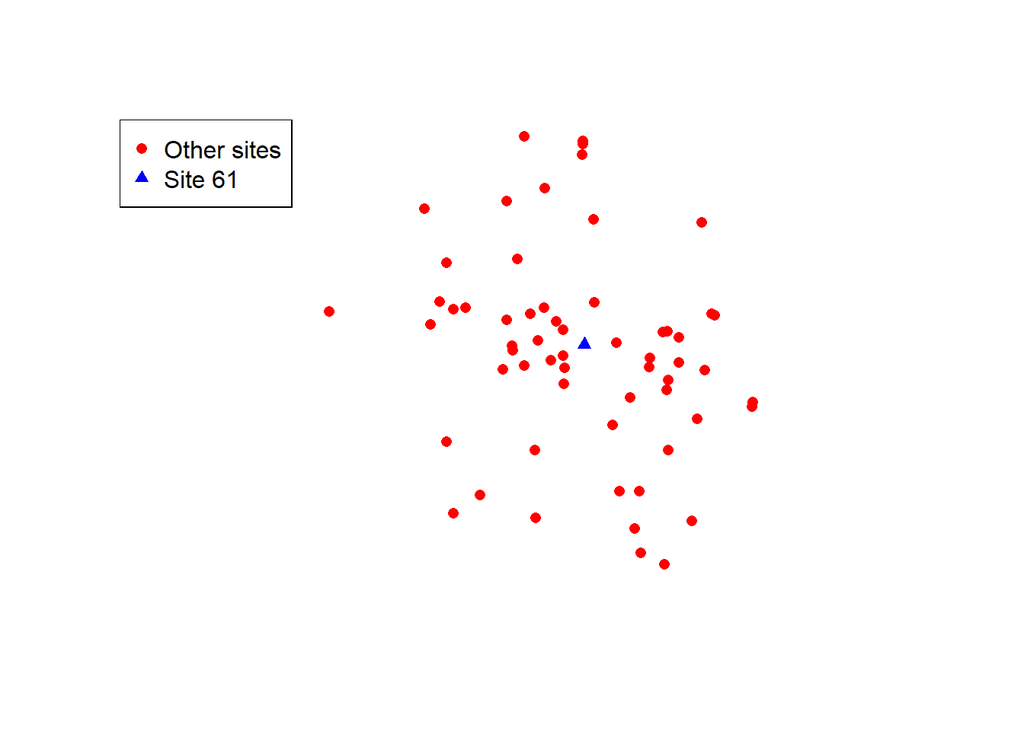

```r
d61_data <- filter(lur_data, site_id == "d_61") %>%
  st_as_sf(wkt = "WKT", crs = albers)
other_data <- filter(lur_data, site_id != "d_61") %>%
  st_as_sf(wkt = "WKT", crs = albers)

plot(st_geometry(other_data), col = "red", pch = 16)
plot(st_geometry(d61_data), col = "blue", add = T, pch = 17)
legend(x = "topleft", c("Other sites", "Site 61"),
       pch = c(16, 17),
       col = c("red", "blue"))
```

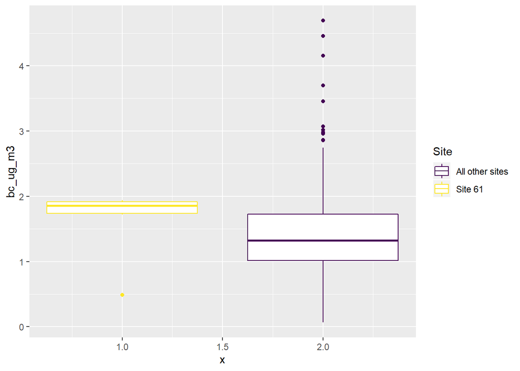

```r
ggplot() +
  geom_boxplot(data = d61_data, aes(x = 1, y = bc_ug_m3, col = "d61")) +
  geom_boxplot(data = other_data, aes(x = 2, y = bc_ug_m3, col = "all")) +
  scale_color_viridis(name = "Site", discrete = T,
                      labels = c("d61" = "Site 61",
                                 "all" = "All other sites"))
```

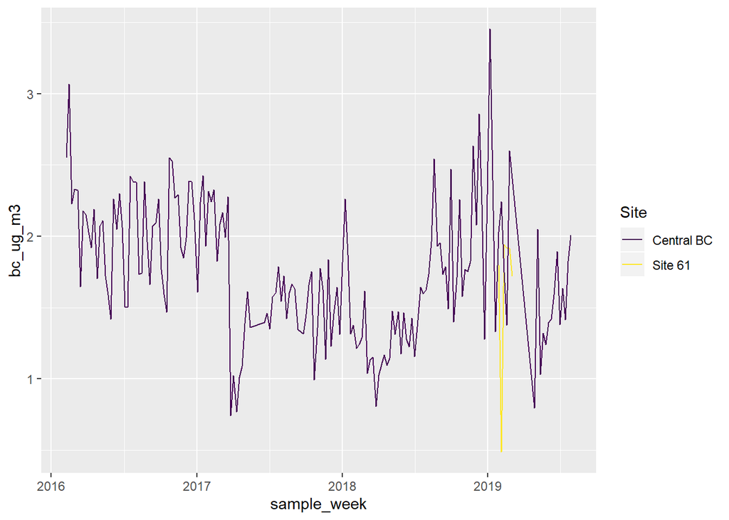

```r
ggplot() +
  geom_line(data = d61_data, aes(x = sample_week, y = bc_ug_m3, col = "d61")) +
  geom_line(data = filter(other_data, filter_id == "080310027"),
            aes(x = sample_week, y = bc_ug_m3, col = "cent")) +
  scale_color_viridis(name = "Site", discrete = T,
                      labels = c("d61" = "Site 61",
                                 "cent" = "Central BC"))
```

```r
#' Filter out site 61
lur_data <- filter(lur_data, site_id != "d_61")
```

Observations of black carbon at the distributed and central sites. Make sure to use log-transformed values!

```r
bc_obs <- lur_data %>%
  select(site_id, sample_week, bc_ug_m3) %>%
  mutate(log_bc = log(bc_ug_m3)) %>%
  select(-bc_ug_m3) %>%
  pivot_wider(id_cols = sample_week,
              names_from = site_id, values_from = log_bc) %>%
  as.data.frame() %>%
  arrange(sample_week)
rownames(bc_obs) <- bc_obs$sample_week
bc_obs$sample_week <- NULL
bc_obs <- as.matrix(bc_obs)

bc_weeks <- rownames(bc_obs)

# rownames(bc_obs)
# colnames(bc_obs)
class(bc_obs)
```

```
## [1] "matrix"
```

```r
dim(bc_obs)
```

```
## [1] 170  61
```

Spatial covariates at the distributed site. These are based on the LASSO model (THIS WILL CHANGE IN THE FUTURE!! I just know how to use LASSO vs. PLS). Make sure the covariates are scaled here.

```r
covars
```

```
## [1] "tree_cover_100"  "low_int_100"     "dist_m_military" "dist_m_rail"
## [5] "aadt_100"
```

```r
bc_sp_cov <- select(lur_data, site_id, lon, lat, covars) %>%
  distinct() %>%
  mutate_at(.vars = vars(covars),
            scale)

bc_sp_cov <- bc_sp_cov %>%
  rename(ID = site_id) %>%
  mutate(lon2 = lon, lat2 = lat) %>%
  st_as_sf(coords = c("lon2", "lat2"), crs = ll_wgs84) %>%
  st_transform(crs = albers)
sp_coords <- do.call(rbind, st_geometry(bc_sp_cov)) %>%
  as_tibble() %>% setNames(c("x","y"))
bc_sp_cov <- bind_cols(bc_sp_cov, sp_coords) %>%
  st_set_geometry(NULL) %>%
  as.data.frame()

bc_sp_cov$type <- ifelse(bc_sp_cov$ID == "central", "central", "dist")
bc_sp_cov$type <- as.factor(bc_sp_cov$type)
bc_sp_cov$type
```

```
##  [1] central dist    dist    dist    dist    dist    dist    dist
##  [9] dist    dist    dist    dist    dist    dist    dist    dist
## [17] dist    dist    dist    dist    dist    dist    dist    dist
## [25] dist    dist    dist    dist    dist    dist    dist    dist
## [33] dist    dist    dist    dist    dist    dist    dist    dist
## [41] dist    dist    dist    dist    dist    dist    dist    dist
## [49] dist    dist    dist    dist    dist    dist    dist    dist
## [57] dist    dist    dist    dist    dist
## Levels: central dist
```

```r
# head(bc_sp_cov)
class(bc_sp_cov)
```

```
## [1] "data.frame"
```

```r
cor(bc_sp_cov[,c(4:8)])
```

```
##                 tree_cover_100 low_int_100 dist_m_military dist_m_rail
## tree_cover_100      1.00000000  0.17021147      0.19563553 -0.02100465
## low_int_100         0.17021147  1.00000000      0.04177673 -0.01893110
## dist_m_military     0.19563553  0.04177673      1.00000000 -0.20139840
## dist_m_rail        -0.02100465 -0.01893110     -0.20139840  1.00000000
## aadt_100           -0.20146284 -0.28464438      0.13117498 -0.19806530
##                   aadt_100
## tree_cover_100  -0.2014628
## low_int_100     -0.2846444
## dist_m_military  0.1311750
## dist_m_rail     -0.1980653
## aadt_100         1.0000000
```

Spatiotemporal covariates at the distributed sites. We have available IDW estimates of temp, NO2, PM2.5, and BC. For now, just using NO2, since the correlations with distribued site log(BC) are decent. I tried to use two ST predictors, but ran into issues trying to fit the model.

```r
cor(log(lur_data$bc_ug_m3), lur_data$idw_no2, use = "complete")
```

```
## [1] 0.4571981
```

```r
cor(log(lur_data$bc_ug_m3), lur_data$idw_pm, use = "complete")
```

```
## [1] 0.1021692
```

```r
cor(log(lur_data$bc_ug_m3), lur_data$idw_temp, use = "complete")
```

```
## [1] -0.5006561
```

### Step 2. create the ST data object and determine the number of basis functions for the temporal trend

For now, going to use one ST predictor (NO2 estimated for each sampling location). Josh advised 4 degrees of freedom per year. Going to check the SVDsmoothCV results for 4 DF per year.

```r
denver.data <- createSTdata(obs = bc_obs,
                            covars = bc_sp_cov,
                            SpatioTemporal = list(bc_st_no2 = bc_st_no2))
D <- createDataMatrix(denver.data)
# names(denver.data)
# print(denver.data)

# Determine the number of basis functions
n_years <- length(unique(as.Date(cut(as.Date(rownames(bc_obs)), "year"))))

SVD.cv.4py <- SVDsmoothCV(D, 0:4, df = 4*n_years)
print(SVD.cv.4py)
```

```
## Result of SVDsmoothCV, average of CV-statistics:
##                  MSE        R2        AIC        BIC
## n.basis.0 0.10864841 0.0000000  -96.64828  -95.45503
## n.basis.1 0.06403040 0.4344894 -109.20041 -106.81393
## n.basis.2 0.04793282 0.5755524 -118.56324 -114.98352
## n.basis.3 0.04046651 0.6517542 -124.15562 -119.38266
## n.basis.4 0.03537937 0.6902925 -124.99747 -119.03126
```

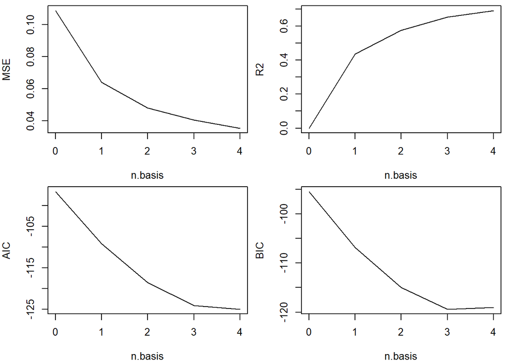

```r
plot(SVD.cv.4py)
```

```r
n_df <- 4
n_basis <- 1

# Add the smooth temporal basis functions to the ST data object
denver.data <- updateTrend(denver.data, n.basis = n_basis, df = n_df*n_years)
```

```
## Replacing existing trend.
```

```r
head(denver.data$trend)
```

```
##          V1       date
## 1 -2.094516 2016-02-08
## 2 -1.931092 2016-02-15
## 3 -1.768524 2016-02-22
## 4 -1.609624 2016-02-29
## 5 -1.457649 2016-03-07
## 6 -1.315808 2016-03-14
```

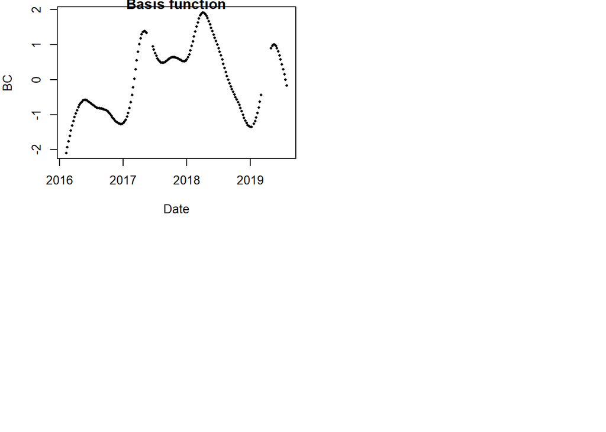

```r
plot(denver.data$trend$date, denver.data$trend$V1, col = 1, pch = 16, cex = 0.5,
     xlab = "Date", ylab = "BC",
     main = "Basis function")
# points(denver.data$trend$date, denver.data$trend$V2, col = 2, pch = 16, cex = 0.5)

layout(matrix(c(1,2,1,3), 2, 2))
```

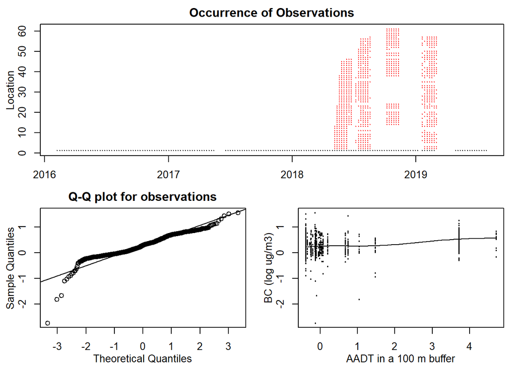

```r
par(mar=c(2.3,3.3,2,1), mgp=c(2,1,0))
plot(denver.data, "loc", main="Occurrence of Observations", xlab="",
     ylab="Location", col=c("black", "red"), legend.loc=NULL)
par(mar=c(3.3,3.3,2,1))
qqnorm(denver.data, line=1)
scatterPlot(denver.data, covar="aadt_100", xlab="AADT in a 100 m buffer",
            ylab="BC (log ug/m3)", pch=19, cex=.25,
            smooth.args=list(span=4/5,degree=2))
```

### Step 3: Evaluate the basis functions

Plotting the temporal trends at a few of the sites

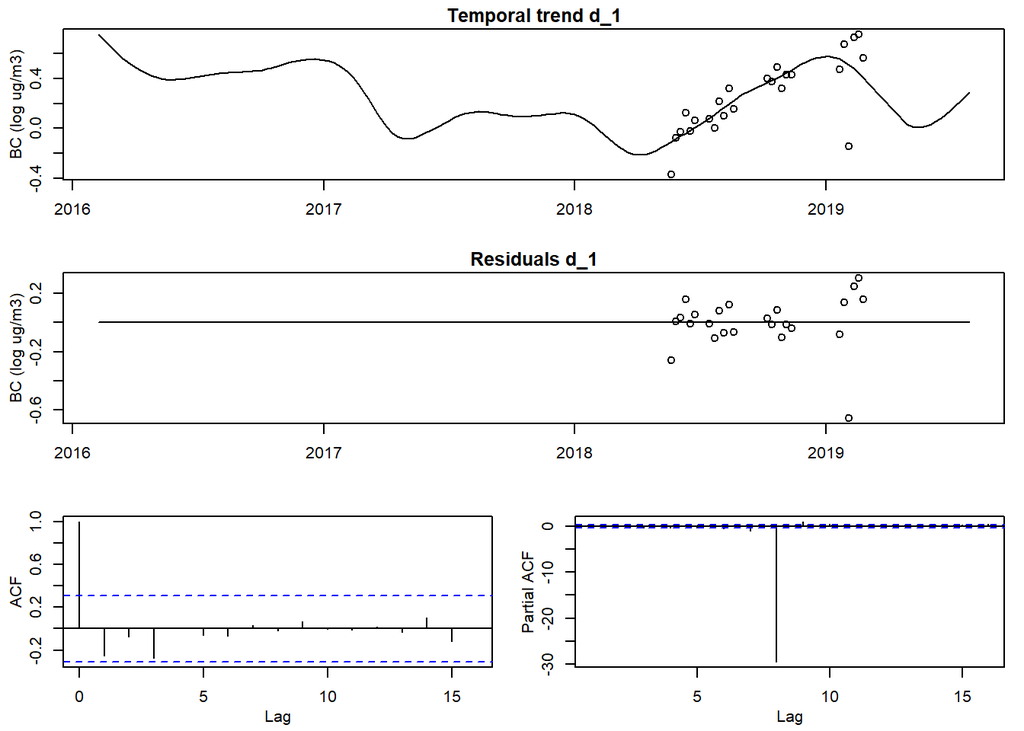

```r
par(mar=c(3.3,3.3,1.5,1), mgp=c(2,1,0))
layout(matrix(c(1,1,2,2,3,4), 3, 2, byrow=TRUE))
plot(denver.data, "obs", ID="d_1", xlab="", ylab="BC (log ug/m3)",
     main="Temporal trend d_1")
plot(denver.data, "res", ID="d_1", xlab="", ylab="BC (log ug/m3)")
plot(denver.data, "acf", ID="d_1")
plot(denver.data, "pacf", ID="d_1")
```

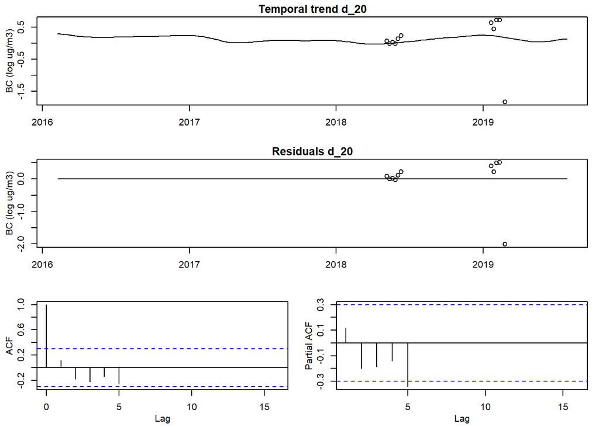

```r
par(mar=c(3.3,3.3,1.5,1), mgp=c(2,1,0))
layout(matrix(c(1,1,2,2,3,4), 3, 2, byrow=TRUE))
plot(denver.data, "obs", ID="d_20", xlab="", ylab="BC (log ug/m3)",
     main="Temporal trend d_20")
plot(denver.data, "res", ID="d_20", xlab="", ylab="BC (log ug/m3)")
plot(denver.data, "acf", ID="d_20")
plot(denver.data, "pacf", ID="d_20")
```

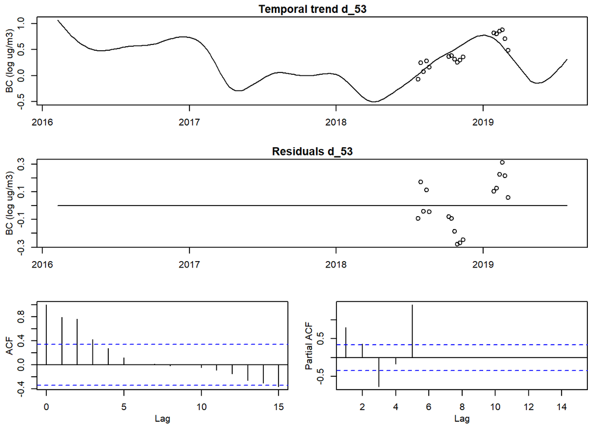

```r
par(mar=c(3.3,3.3,1.5,1), mgp=c(2,1,0))
layout(matrix(c(1,1,2,2,3,4), 3, 2, byrow=TRUE))
plot(denver.data, "obs", ID="d_53", xlab="", ylab="BC (log ug/m3)",
     main="Temporal trend d_53")
plot(denver.data, "res", ID="d_53", xlab="", ylab="BC (log ug/m3)")
plot(denver.data, "acf", ID="d_53")
plot(denver.data, "pacf", ID="d_53")
```

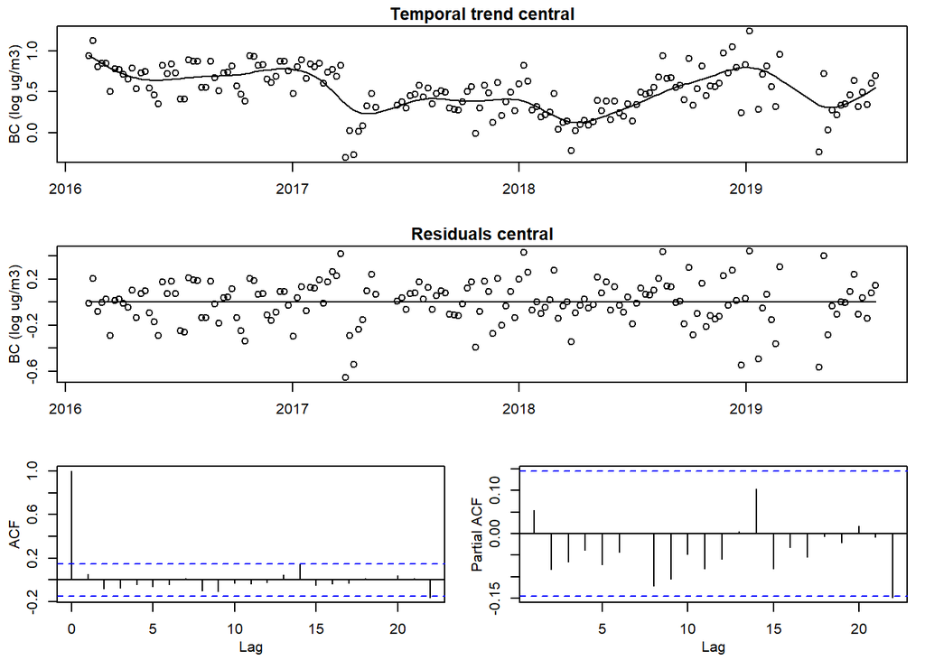

```r
par(mar=c(3.3,3.3,1.5,1), mgp=c(2,1,0))
layout(matrix(c(1,1,2,2,3,4), 3, 2, byrow=TRUE))
plot(denver.data, "obs", ID="central", xlab="", ylab="BC (log ug/m3)",
     main="Temporal trend central")
plot(denver.data, "res", ID="central", xlab="", ylab="BC (log ug/m3)")
plot(denver.data, "acf", ID="central")
plot(denver.data, "pacf", ID="central")
```

### Step 4: Fit the model

#### Step 4.1: Compute the regression coefficients

```r
names(denver.data$covars)
```

```
##  [1] "ID"              "lon"             "lat"
##  [4] "tree_cover_100"  "low_int_100"     "dist_m_military"
##  [7] "dist_m_rail"     "aadt_100"        "x"
## [10] "y"               "type"
```

```r
beta.lm <- estimateBetaFields(denver.data)
# beta_lm
head(beta.lm$beta)
```

```
##             const          V1
## central 0.5176495 -0.20598504
## d_1     0.2489351 -0.23993688
## d_10    0.2024595 -0.31739607
## d_11    0.2234871 -0.14343993
## d_12    0.2161249 -0.36020758
## d_13    0.1851210 -0.08111586
```

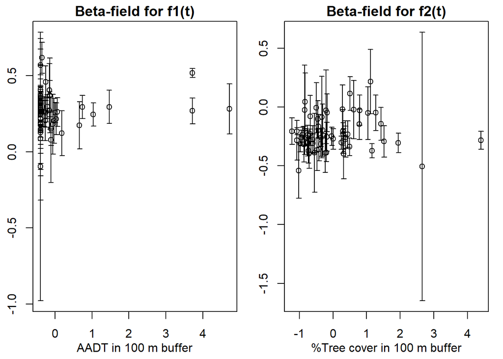

```r
par(mfrow=c(1,2), mar=c(3.3,2.3,1.5,1), mgp=c(2,1,0))
plotCI(denver.data$covars$aadt_100, beta.lm$beta[,1],
       uiw=1.96*beta.lm$beta.sd[,1], ylab="", xlab="AADT in 100 m buffer",
       main="Beta-field for f1(t)")
plotCI(denver.data$covars$tree_cover_100, beta.lm$beta[,2],
       uiw=1.96*beta.lm$beta.sd[,2], ylab="", xlab="%Tree cover in 100 m buffer",
       main="Beta-field for f2(t)")
```

#### Step 4.2: Create the model object (iid covariance structure)

Here we can specify different LUR formluae. The length of the LUR list should be number of basis functions + 1. I’m going to start with the `iid` covariance structure and will be setting `nugget = T`.

```r
names(denver.data$covars)
```

```
##  [1] "ID"              "lon"             "lat"
##  [4] "tree_cover_100"  "low_int_100"     "dist_m_military"
##  [7] "dist_m_rail"     "aadt_100"        "x"
## [10] "y"               "type"
```

```r
LUR <- list(~tree_cover_100 + low_int_100 + dist_m_military + dist_m_rail + aadt_100,
            ~tree_cover_100 + low_int_100 + dist_m_military + dist_m_rail + aadt_100)
cov.beta <-  list(covf="iid", nugget = T)
cov.nu <- list(covf="iid", nugget = T, random.effect = FALSE)
locations <- list(coords = c("x","y"), long.lat = c("lon","lat"), others= "type")

denver.model.iid <- createSTmodel(denver.data, LUR = LUR,
                                  ST = "bc_st_no2",
                                  cov.beta = cov.beta, cov.nu = cov.nu,
                                  locations = locations)
denver.model.iid
```

```
## STmodel-object with:
##  No. locations: 61 (observed: 61)
##  No. time points: 170 (observed: 170)
##  No. obs: 1165
##
## Trend with 1 basis function(s):
## [1] "V1"
## with dates:
##  2016-02-08 to 2019-07-29
##
## Models for the beta-fields are:
## $const
## ~tree_cover_100 + low_int_100 + dist_m_military + dist_m_rail +
##     aadt_100
##
## $V1
## ~tree_cover_100 + low_int_100 + dist_m_military + dist_m_rail +
##     aadt_100
##
## 1 spatio-temporal covariate(s):
## [1] "bc_st_no2"
##
## Covariance model for the beta-field(s):
##  Covariance type(s): iid, iid
##  Nugget: Yes, Yes
## Covariance model for the nu-field(s):
##  Covariance type: iid
##  Nugget: ~1
##  Random effect: No
## All sites:
## central    dist
##       1      60
## Observed:
## central    dist
##       1      60
##
## For central:
##   Number of obs: 169
##   Dates: 2016-02-08 to 2019-07-29
## For dist:
##   Number of obs: 996
##   Dates: 2018-05-07 to 2019-03-04
```

#### Step 4.3: Estimate model parameters (iid model)

Josh gave some guidance on how to set up the intial values:

- nugget values can range from -1 to -6
- range values can range from 0 to 4

Based on the tutorial, it looks like sill values should be similar to nugget values

We want to try a number of initial conditions to make sure we find the “right” solution.

```r
dim <- loglikeSTdim(denver.model.iid)
# dim
names <- loglikeSTnames(denver.model.iid, all=FALSE)
names
```

```
## [1] "log.nugget.const.iid"          "log.nugget.V1.iid"
## [3] "nu.log.nugget.(Intercept).iid"
```

```r
x.init.iid <- cbind(c(rep(-1, 3)), c(rep(-2, 3)), c(rep(-3, 3)),
                    c(rep(-4, 3)), c(rep(-5, 3)), c(rep(-6, 3)))
x.init.iid[nrow(x.init.iid),] <- 0

rownames(x.init.iid) <- loglikeSTnames(denver.model.iid, all=FALSE)
x.init.iid
```

```
##                               [,1] [,2] [,3] [,4] [,5] [,6]
## log.nugget.const.iid            -1   -2   -3   -4   -5   -6
## log.nugget.V1.iid               -1   -2   -3   -4   -5   -6
## nu.log.nugget.(Intercept).iid    0    0    0    0    0    0
```

```r
#' Difference from tutorial: use Josh Keller's version of the function
source(here::here("Code", "functions_model.R"))
est.denver.model.iid <- estimate.STmodel(denver.model.iid, x.init.iid)
```

```
## Optimisation using starting value 1/6
```

[output not shown]

```
## Optimisation using starting value 2/6
```

[output not shown]

```
## Optimisation using starting value 3/6
```

[output not shown]

```
## Optimisation using starting value 4/6
```

[output not shown]

```
## Optimisation using starting value 5/6
```

[output not shown]

```
## Optimisation using starting value 6/6
```

[output not shown]

```r
print(est.denver.model.iid)
```

```
## Optimisation for STmodel with 6 starting points.
##   Results: 6 converged, 0 not converged, 0 failed.
##   Best result for starting point 1, optimisation has converged
##
## No fixed parameters.
##
## Estimated parameters for all starting point(s):
##                                        [,1]          [,2]          [,3]
## gamma.bc_st_no2               -0.0060345713 -0.0060358504 -0.0060358336
## alpha.const.(Intercept)        0.3922408907  0.3922638915  0.3922636048
## alpha.const.tree_cover_100    -0.0212308967 -0.0212278157 -0.0212277981
## alpha.const.low_int_100       -0.0046219057 -0.0046238264 -0.0046238036
## alpha.const.dist_m_military   -0.0011402906 -0.0011398552 -0.0011398042
## alpha.const.dist_m_rail        0.0003158104  0.0003160276  0.0003160487
## alpha.const.aadt_100           0.0526363119  0.0526195660  0.0526197171
## alpha.V1.(Intercept)          -0.2709281571 -0.2709374638 -0.2709374506
## alpha.V1.tree_cover_100        0.0259664661  0.0259646166  0.0259646303
## alpha.V1.low_int_100           0.0101342317  0.0101351259  0.0101350975
## alpha.V1.dist_m_military      -0.0071313826 -0.0071274952 -0.0071274516
## alpha.V1.dist_m_rail          -0.0457861182 -0.0457861490 -0.0457860735
## alpha.V1.aadt_100              0.0434430853  0.0434478688  0.0434473561
## log.nugget.const.iid          -6.7469400438 -6.7415490668 -6.7416142787
## log.nugget.V1.iid             -6.0325178098 -6.0323082237 -6.0323483631
## nu.log.nugget.(Intercept).iid -2.7546251321 -2.7548708281 -2.7548569740
##                                        [,4]          [,5]          [,6]
## gamma.bc_st_no2               -0.0060358865 -0.0060358742 -0.0060359922
## alpha.const.(Intercept)        0.3922646001  0.3922643407  0.3922665451
## alpha.const.tree_cover_100    -0.0212275131 -0.0212276801 -0.0212271011
## alpha.const.low_int_100       -0.0046238902 -0.0046238656 -0.0046240563
## alpha.const.dist_m_military   -0.0011396329 -0.0011397708 -0.0011394440
## alpha.const.dist_m_rail        0.0003161226  0.0003160639  0.0003162054
## alpha.const.aadt_100           0.0526188387  0.0526191624  0.0526172702
## alpha.V1.(Intercept)          -0.2709381312 -0.2709377838 -0.2709391957
## alpha.V1.tree_cover_100        0.0259645250  0.0259645679  0.0259643434
## alpha.V1.low_int_100           0.0101350898  0.0101351202  0.0101351192
## alpha.V1.dist_m_military      -0.0071270344 -0.0071272954 -0.0071264569
## alpha.V1.dist_m_rail          -0.0457858715 -0.0457860485 -0.0457856709
## alpha.V1.aadt_100              0.0434463393  0.0434473532  0.0434455223
## log.nugget.const.iid          -6.7414027586 -6.7414301113 -6.7408546263
## log.nugget.V1.iid             -6.0324672734 -6.0323433402 -6.0324630285
## nu.log.nugget.(Intercept).iid -2.7548649892 -2.7548498465 -2.7547688134
##
## Function value(s):
## [1] 1000.004 1000.004 1000.004 1000.004 1000.004 1000.004
```

#### Step 4.4: Create the model object (exp covariance structure)

Now I’m using the `exp` covariance structure and setting `nugget = T`.

```r
names(denver.data$covars)
```

```
##  [1] "ID"              "lon"             "lat"
##  [4] "tree_cover_100"  "low_int_100"     "dist_m_military"
##  [7] "dist_m_rail"     "aadt_100"        "x"
## [10] "y"               "type"
```

```r
LUR <- list(~tree_cover_100 + low_int_100 + dist_m_military + dist_m_rail + aadt_100,
            ~tree_cover_100 + low_int_100 + dist_m_military + dist_m_rail + aadt_100)
cov.beta <-  list(covf="exp", nugget = T)
cov.nu <- list(covf="exp", nugget = T, random.effect = FALSE)
locations <- list(coords = c("x","y"), long.lat = c("lon","lat"), others= "type")

denver.model.exp <- createSTmodel(denver.data, LUR = LUR,
                                  ST = "bc_st_no2",
                                  cov.beta = cov.beta, cov.nu = cov.nu,
                                  locations = locations)
denver.model.exp
```

```
## STmodel-object with:
##  No. locations: 61 (observed: 61)
##  No. time points: 170 (observed: 170)
##  No. obs: 1165
##
## Trend with 1 basis function(s):
## [1] "V1"
## with dates:
##  2016-02-08 to 2019-07-29
##
## Models for the beta-fields are:
## $const
## ~tree_cover_100 + low_int_100 + dist_m_military + dist_m_rail +
##     aadt_100
##
## $V1
## ~tree_cover_100 + low_int_100 + dist_m_military + dist_m_rail +
##     aadt_100
##
## 1 spatio-temporal covariate(s):
## [1] "bc_st_no2"
##
## Covariance model for the beta-field(s):
##  Covariance type(s): exp, exp
##  Nugget: Yes, Yes
## Covariance model for the nu-field(s):
##  Covariance type: exp
##  Nugget: ~1
##  Random effect: No
## All sites:
## central    dist
##       1      60
## Observed:
## central    dist
##       1      60
##
## For central:
##   Number of obs: 169
##   Dates: 2016-02-08 to 2019-07-29
## For dist:
##   Number of obs: 996
##   Dates: 2018-05-07 to 2019-03-04
```

#### Step 4.5: Estimate model parameters (exp model)

I ran this model first with the same range of starting values as the `iid` model above. However, I got this warning message:

`## Warning in res[[i]][[par.type]]$sd[is.na(x.fixed)] <- par.sd: number of` `## items to replace is not a multiple of replacement length`

One of the starting value sets did work (9), so I’m trying again with an updated set of intial values based on that run:

```r
## log.range.const.exp              3.92492519
## log.sill.const.exp              -8.51427937
## log.nugget.const.exp           -15.00000000
## log.range.V1.exp                 3.99913233
## log.sill.V1.exp                -15.00000000
## log.nugget.V1.exp              -15.00000000
## nu.log.range.exp                 9.48994997
## nu.log.sill.exp                 -3.79999900
## nu.log.nugget.(Intercept).exp   -3.10670337
```

```r
dim <- loglikeSTdim(denver.model.exp)
# dim
names <- loglikeSTnames(denver.model.exp, all=FALSE)
names
```

```
## [1] "log.range.const.exp"           "log.sill.const.exp"
## [3] "log.nugget.const.exp"          "log.range.V1.exp"
## [5] "log.sill.V1.exp"               "log.nugget.V1.exp"
## [7] "nu.log.range.exp"              "nu.log.sill.exp"
## [9] "nu.log.nugget.(Intercept).exp"
```

```r
x.init.exp <- cbind(c(rep(c(4, -5, -5), 3)),
                    c(rep(c(4, -5, -6), 3)),
                    c(rep(c(4, -6, -6), 3)),
                    c(rep(c(4, -6, -7), 3)),
                    c(rep(c(4, -7, -7), 3)),
                    c(rep(c(4, -7, -8), 3)),
                    c(rep(c(4, -8, -8), 3)))
x.init.exp[nrow(x.init.exp),] <- -3

rownames(x.init.exp) <- loglikeSTnames(denver.model.exp, all=FALSE)
x.init.exp
```

```
##                               [,1] [,2] [,3] [,4] [,5] [,6] [,7]
## log.range.const.exp              4    4    4    4    4    4    4
## log.sill.const.exp              -5   -5   -6   -6   -7   -7   -8
## log.nugget.const.exp            -5   -6   -6   -7   -7   -8   -8
## log.range.V1.exp                 4    4    4    4    4    4    4
## log.sill.V1.exp                 -5   -5   -6   -6   -7   -7   -8
## log.nugget.V1.exp               -5   -6   -6   -7   -7   -8   -8
## nu.log.range.exp                 4    4    4    4    4    4    4
## nu.log.sill.exp                 -5   -5   -6   -6   -7   -7   -8
## nu.log.nugget.(Intercept).exp   -3   -3   -3   -3   -3   -3   -3
```

```r
#' Difference from tutorial: use Josh Keller's version of the function
source(here::here("Code", "functions_model.R"))
est.denver.model.exp <- estimate.STmodel(denver.model.exp, x.init.exp)
```

```
## Optimisation using starting value 1/7
```

[output not shown]

```
## Optimisation using starting value 2/7
```

[output not shown]

```
## Optimisation using starting value 3/7
```

[output not shown]

```
## Optimisation using starting value 4/7
```

[output not shown]

```
## Optimisation using starting value 5/7
```

[output not shown]

```
## Optimisation using starting value 6/7
```

[output not shown]

```
## Optimisation using starting value 7/7
```

[output not shown]

```r
print(est.denver.model.exp)
```

```
## Optimisation for STmodel with 7 starting points.
##   Results: 6 converged, 1 not converged, 0 failed.
##   Best result for starting point 6, optimisation has converged
##
## No fixed parameters.
##
## Estimated parameters for all starting point(s):
##                                        [,1]          [,2]          [,3]
## gamma.bc_st_no2                -0.004978217  -0.004984989  -0.004977825
## alpha.const.(Intercept)         0.373141160   0.373255956   0.373105489
## alpha.const.tree_cover_100     -0.009103212  -0.009075725  -0.009095222
## alpha.const.low_int_100        -0.014685370  -0.014691370  -0.014683307
## alpha.const.dist_m_military     0.004244655   0.004255377   0.004249243
## alpha.const.dist_m_rail         0.002755091   0.002763736   0.002760520
## alpha.const.aadt_100            0.051154568   0.051067390   0.051116461
## alpha.V1.(Intercept)           -0.282818625  -0.282955752  -0.282825648
## alpha.V1.tree_cover_100         0.013922490   0.013890475   0.013914868
## alpha.V1.low_int_100            0.014215995   0.014217769   0.014215032
## alpha.V1.dist_m_military       -0.009489456  -0.009478382  -0.009486611
## alpha.V1.dist_m_rail           -0.036768014  -0.036736504  -0.036763435
## alpha.V1.aadt_100               0.033072082   0.032893972   0.032995551
## log.range.const.exp             3.686934325   3.348801936   3.987142078
## log.sill.const.exp             -7.151637969  -7.130208901  -7.139526479
## log.nugget.const.exp          -11.303372901 -14.237448205 -12.564557229
## log.range.V1.exp                4.013393706   4.015638111   4.012767867
## log.sill.V1.exp               -10.090273605 -13.837854323 -11.375108986
## log.nugget.V1.exp              -7.075015459  -7.058569847  -7.051857384
## nu.log.range.exp                9.359570529   9.360772174   9.358864618
## nu.log.sill.exp                -3.828900862  -3.827793961  -3.828623658
## nu.log.nugget.(Intercept).exp  -3.171728298  -3.171894185  -3.171890401
##                                        [,4]          [,5]          [,6]
## gamma.bc_st_no2                -0.004983852  -0.004979204  -0.004978321
## alpha.const.(Intercept)         0.373217161   0.373129451   0.373099888
## alpha.const.tree_cover_100     -0.009095740  -0.009106142  -0.009096861
## alpha.const.low_int_100        -0.014681704  -0.014684703  -0.014683707
## alpha.const.dist_m_military     0.004250767   0.004245628   0.004251059
## alpha.const.dist_m_rail         0.002762376   0.002759695   0.002762421
## alpha.const.aadt_100            0.051067917   0.051142923   0.051098307
## alpha.V1.(Intercept)           -0.282895880  -0.282813050  -0.282820941
## alpha.V1.tree_cover_100         0.013907577   0.013919065   0.013914984
```

[output cut: 24 more lines]

```
## alpha.V1.dist_m_military       -0.009479045
## alpha.V1.dist_m_rail           -0.036757639
## alpha.V1.aadt_100               0.032985813
## log.range.const.exp             4.062170677
## log.sill.const.exp             -7.136648070
## log.nugget.const.exp          -11.825174623
## log.range.V1.exp                4.024671397
## log.sill.V1.exp               -15.000000000
## log.nugget.V1.exp              -7.040929814
## nu.log.range.exp                9.359729901
## nu.log.sill.exp                -3.828246397
## nu.log.nugget.(Intercept).exp  -3.171799998
##
## Function value(s):
## [1] 1065.761 1065.781 1065.776 1065.782 1065.767 1065.782 1065.775
```

### Step 5: Predictions

In order to get this to work, I’m going to use with `only.obs = T` option. When I tried to use the predict function without setting `only.obs = T`, I got NA values in each of the columns for the pred$LAT object.

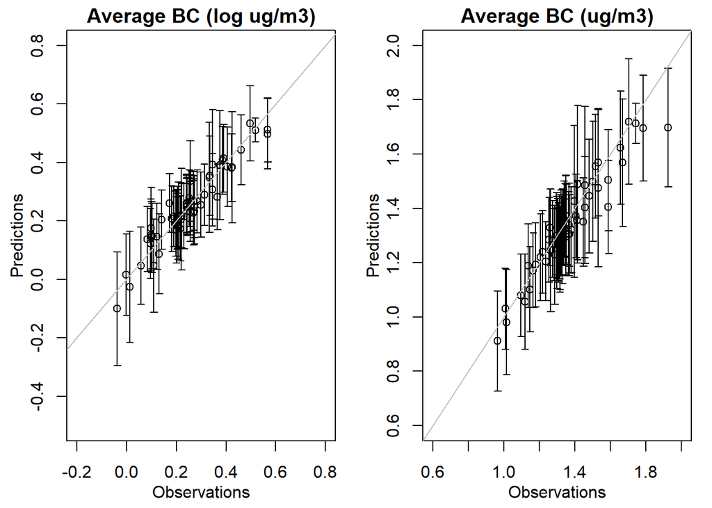

```r
pred <- predict(denver.model.exp, est.denver.model.exp, denver.data,
                only.obs = T, LTA = T, type = "p")
pred.log <- predict(denver.model.exp, est.denver.model.exp, denver.data,
                    only.obs = T, LTA = T,
                    transform = "unbiased", type = "p")

par(mfrow=c(1,2), mar=c(3.3,3.3,1.5,1), mgp=c(2,1,0))
with(pred$LTA, plotCI(colMeans(D, na.rm=TRUE), EX, uiw=1.96*sqrt(VX.pred),
                      xlim=c(-0.2,0.8), ylim=c(-0.5,0.8),
                      ylab="Predictions", xlab="Observations",
                      main="Average BC (log ug/m3)"))
abline(0, 1, col="grey")
with(pred.log$LTA, plotCI(colMeans(exp(D), na.rm=TRUE),
                          EX, uiw=1.96*sqrt(VX.pred),
                          xlim=c(0.6,2), ylim=c(0.6,2),
                          ylab="Predictions", xlab="Observations",
                          main="Average BC (ug/m3)"))
abline(0, 1, col="grey")
```

### Step 6: Cross-validation and model evaluation

Josh recommended 10-fold CV for the distributed sites and LOOCV for the monitor.

#### Step 6.1: Define CV groups

```r
Ind.cv <- createCV(denver.model.exp, groups = 10, min.dist = .1,
                   subset = paste0("d_", 1:60))
```

The number of locations is roughly even, though the number of observations differs by group– remember! This is an unbalanced design

```r
ID.cv <- sapply(split(denver.model.exp$obs$ID, Ind.cv), unique)
print(sapply(ID.cv, length))
```

```
##  0  1  2  3  4  5  6  7  8  9 10
##  1  6  6  6  6  6  6  6  6  6  6
```

```r
table(Ind.cv)
```

```
## Ind.cv
##   0   1   2   3   4   5   6   7   8   9  10
## 169 100 103 106 117 106  83  87  88  96 110
```

#### Step 6.2: ID starting conditions using previous model without CV

```r
x.init.cv <- coef(est.denver.model.exp, pars="cov")[,c("par","init")]
x.init.cv
```

```
##                                      par init
## log.range.const.exp             3.671919    4
## log.sill.const.exp             -7.133773   -7
## log.nugget.const.exp          -15.000000   -8
## log.range.V1.exp                4.043723    4
## log.sill.V1.exp               -15.000000   -7
## log.nugget.V1.exp              -7.039262   -8
## nu.log.range.exp                9.358891    4
## nu.log.sill.exp                -3.828485   -7
## nu.log.nugget.(Intercept).exp  -3.171942   -3
```

#### Step 6.3 : Run the model

```r
est.denver.cv.exp <- estimateCV(denver.model.exp, x.init.cv, Ind.cv)
```

```
## Estimation of CV-set 1/10
```

```
## Optimisation using starting value 1/2
```

[output not shown]

```
## Optimisation using starting value 2/2
```

[output not shown]

```
## Estimation of CV-set 2/10
```

```
## Optimisation using starting value 1/2
```

[output not shown]

```
## Optimisation using starting value 2/2
```

[output not shown]

```
## Estimation of CV-set 3/10
```

```
## Optimisation using starting value 1/2
```

[output not shown]

```
## Optimisation using starting value 2/2
```

[output not shown]

```
## Estimation of CV-set 4/10
```

```
## Optimisation using starting value 1/2
```

[output not shown]

```
## Optimisation using starting value 2/2
```

[output not shown]

```
## Estimation of CV-set 5/10
```

```
## Optimisation using starting value 1/2
```

[output not shown]

```
## Optimisation using starting value 2/2
```

[output not shown]

```
## Estimation of CV-set 6/10
```

```
## Optimisation using starting value 1/2
```

[output not shown]

```
## Optimisation using starting value 2/2
```

[output not shown]

```
## Estimation of CV-set 7/10
```

```
## Optimisation using starting value 1/2
```

[output not shown]

```
## Optimisation using starting value 2/2
```

[output not shown]

```
## Estimation of CV-set 8/10
```

```
## Optimisation using starting value 1/2
```

[output not shown]

```
## Optimisation using starting value 2/2
```

[output not shown]

```
## Estimation of CV-set 9/10
```

```
## Optimisation using starting value 1/2
```

[output not shown]

```
## Optimisation using starting value 2/2
```

[output not shown]

```
## Estimation of CV-set 10/10
```

```
## Optimisation using starting value 1/2
```

[output not shown]

```
## Optimisation using starting value 2/2
```

[output not shown]

```r
print(est.denver.cv.exp)
```

```
## Cross-validation parameter estimation for STmodel
##   with 10 CV-groups and 2 starting points.
##   Results: 2 converged, 8 not converged.
##
## No fixed parameters.
##
## Estimated function values and convergence info:
##        value convergence  conv     eigen.min eigen.all.min
## 1   943.6971        TRUE FALSE -1.614598e-06            NA
## 2   974.8011        TRUE  TRUE  6.811351e-07            NA
## 3   971.2934        TRUE FALSE -3.554698e-07            NA
## 4  1020.3481        TRUE  TRUE  7.329791e-07            NA
## 5   947.9957        TRUE FALSE -2.664497e-04            NA
## 6   973.0601        TRUE FALSE -4.350424e-04            NA
## 7   987.2442        TRUE FALSE -2.863618e-06            NA
## 8  1020.9731        TRUE FALSE -2.928923e-04            NA
## 9   960.0610        TRUE FALSE -1.199639e-06            NA
## 10  947.3075        TRUE FALSE -7.303305e-06            NA
```

```r
#' Save the results as an .rdata object
save(denver.data, denver.model.iid, denver.model.exp,
     est.denver.model.iid, est.denver.model.exp,
     est.denver.cv.exp,
     file = here::here("Results", "Denver_ST_Model.rdata"))

# par(mfrow=c(1,1), mar=c(13.5,2.5,.5,.5), las=2)
# with(coef(est.denver.model.exp, pars="all"),
#      plotCI((1:length(par))+.3, par, uiw=1.96*sd,
#             col=2, xlab="", xaxt="n", ylab=""))
# boxplot(est.cv.denver, "all", boxwex=.4, col="grey", add=TRUE)
```